# CMAR Standard Operating Procedures: Trim and format sensor string data using the `strings` package

SOP011

Danielle Dempsey. Nicole Torrie

2021-01-20

[figure not shown]

```r
library(strings)
library(dplyr)
```

## 1. **PURPOSE**

`strings` is an R package developed to help users compile, format, calculate, and visualize oceanographic data collected by the Centre for Marine Applied REsearch’s (CMAR) Coastal Monitoring Program. The package can process temperature, dissolved oxygen, and salinity data measured by HOBO Pro V2, TidBiT, aquaMeasure DOT, aquaMeasure SAL, and/or VR2AR sensors from a single sensor string deployment.

The purpose of this vignette is to provide detailed instruction on how to trim compiled Coastal Monitoring Program data following CMAR’s workflow. The trimmed data is exported to the deployment folder and also formatted and exported to the appropriate Open Data Portal county folder.

Detailed instruction on how to compile data is in SOP010.

Section 3.1 provides a general overview of the `trim_data()` function. Section 3.2 is CMAR-specific, and shows how to trim and export Coastal Monitoring Program data using a template.

## 2. **SCOPE/PRINCIPAL**

1. `trim_data()` function
2. CMAR work flow: `Trim_Template.R`

## 3. **PROCEDURE**

### 3.1 **The `trim_data()` function**

The `trim_data()` function trims the compiled data (in long/tidy format) to specified dates by filtering on the `TIMESTAMP` column. The function will only trim one variable at a time, so this function works best in a pipeline. You must also specify which sensors to trim.

See `?trim_data` for more detail on function arguments.

Start and end times of the raw data:

```r
wide_data %>%
  convert_to_tidydata() %>%
  group_by(VARIABLE) %>%
  summarise(MIN_TIMESTAMP = min(TIMESTAMP), MAX_TIMESTAMP = max(TIMESTAMP))
```

```
#> # A tibble: 2 x 3
#>   VARIABLE         MIN_TIMESTAMP       MAX_TIMESTAMP
#>   <chr>            <dttm>              <dttm>
#> 1 Dissolved Oxygen 2019-05-30 00:59:00 2019-10-19 15:16:00
#> 2 Temperature      2019-05-30 00:59:00 2019-10-19 15:11:00
```

In this example, all variables are trimmed to the same start and end times. This does not have to be the case - you can provide different start/end times for each variable in the different sections of the pipe.

```r
# specify the timestamp for the FIRST VALID measurement
# (this can be copy/pasted from the _raw.csv file)
start.timestamp <- "2019-05-30  7:34:00 PM"

# specify the timestamp for the LAST VALID measurement
# (this can be copy/pasted from the _raw.csv file)
last.timestamp <- "2019-10-19  2:01:00 PM"

# sensors that recorded temperature data that should be trimmed
sensors.temp <- c("HOBO", "aquaMeasure", "VR2AR")

# sensors that recorded dissolved oxygen data that should be trimmed
sensors.DO <- c("aquaMeasure")

# info to trim the salinity data
sensors.sal <- c("aquaMeasure")

# convert the wide data to long data
dat_trim <- wide_data %>%
  convert_to_tidydata() %>%
  # trim temperature data
  trim_data(var.to.trim = "Temperature",
            start.datetime = start.timestamp ,
            end.datetime = last.timestamp,
            sensors.to.trim = sensors.temp) %>%
  # trim DO data
  trim_data(var.to.trim = "Dissolved Oxygen",
            start.datetime = start.timestamp ,
            end.datetime = last.timestamp,
            sensors.to.trim = sensors.DO) #%>%
  # # trim salinity data
  # trim_data(var.to.trim = "Salinity",
  #           start.datetime = start.timestamp ,
  #           end.datetime = last.timestamp,
  #           sensors.to.trim = sensors.sal)
```

Start and end times of the trimmed data:

```r
dat_trim %>%
  group_by(VARIABLE) %>%
  summarise(MIN_TIMESTAMP = min(TIMESTAMP), MAX_TIMESTAMP = max(TIMESTAMP))
```

```
#> # A tibble: 2 x 3
#>   VARIABLE         MIN_TIMESTAMP       MAX_TIMESTAMP
#>   <chr>            <dttm>              <dttm>
#> 1 Dissolved Oxygen 2019-05-30 20:15:00 2019-10-19 13:14:00
#> 2 Temperature      2019-05-30 20:00:00 2019-10-19 14:00:00
```

An error will be printed if you try to trim a variable from a sensor that did not measure that variable.

### 3.2 CMAR Workflow: `Trim_Template.R`

Before trimming: * Check the STRING TRACKER to determine which deployments are a priority for sending to Open Data.

Trimming data for a single deployment should be done by following `Trim_Template.R` saved in the “Y:/Coastal Monitoring Program/Strings Files/Templates” folder. This will export the trimmed data to the deployment folder and the Open Data folder. We will walk through each of the sections here.

Open `Trim_Template.R`.

Save the file into the deployment folder with the name structure: “Trim_Deployment_Location_yyyy-mm-dd.R”.

[figure not shown]

Figure 1. Save `Trim_Template.R` into the deployment folder of the string you are processing and re-name.

At the top of `Trim_Template.R`, fill in the current date, your name, the version of the `strings` package you are using, and any additional notes you deem necessary for future data management.

```r
# DATE: 2020-Sep-02
# NAME: DD
# strings VERSION: 1.1.0
# NOTES:
```

The next comments describe the sections of the script:

```r
# Template for trimming data compiled from a sensor string deployment
# Returns trimmed data as a csv file in the final folder on path
# and in the appropriate county folder for transfer to Open Data Portal

# SECTION 1: Import and visualize raw data

# SECTION 2: Trim data

# SECTION 3: Visualize and Export trimmed data

# SECTION 4: Export for Open Data
```

Load the necessary libraries

```r
# libraries
library(dplyr)         # to pipe and manipulate data
library(readr)         # to read and write csv files
library(strings)       # for string data functions
library(ggplot2)       # for DO plot
library(lubridate)     # for DO plot
library(googlesheets4) # for county info
```

**Section 1:** Update the `path` variable to the deployment folder you are processing. You do not need to change the `path.export` variable.

```r
# Section 1: Import and visualize raw data ---------------------------------------------------------------

# path to the raw data file
path <- file.path("Y:/Coastal Monitoring Program/Data_Strings/Birchy Head/Birchy Head 2019-05-02")

# path to export the trimmed and formatted data (county name pasted on below)
path.export <- file.path("Y:/Coastal Monitoring Program/Open Data/")
```

Change the file name to the name of the raw data .csv file, but **without** the "_raw".

```r
# Raw data ----------------------------------------------------------------

# file name
file.name <- "Birchy Head_2019-05-02_TEMP_DO"
```

Import the raw data file.

```r
# import raw data
dat_raw <- read_csv(paste(path, "/", file.name, "_raw.csv", sep = ""),
                    col_names = FALSE)
```

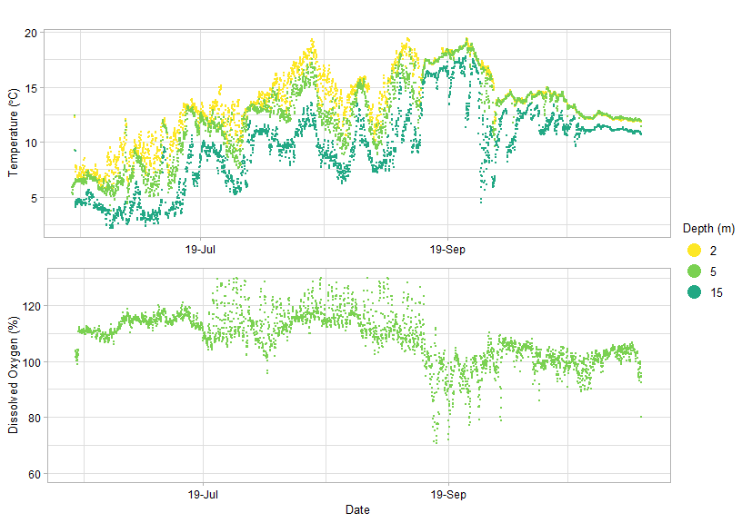

```r
dat_raw <- convert_to_tidydata(dat_raw)

# plot raw data
plot_variables_at_depth(dat_raw,
                        vars.to.plot = c("Temperature", "Dissolved Oxygen"))
```

**Section 2:** Determine where to trim the data for each variable. This can be an iterative process. Use the figure from the previous step to get a general idea of when to trim (e.g., the approximate value of the first reliable measurements), and the raw .csv file to determine the timestamps of the first and last reliable measurements.

[output not shown]

Check the temperature data from the other sensors to make sure this timestamp is appropriate, and adjust it if necessary.